# Composição/diversidade de comunidades de abelhas em função da estrutura da paisagem

Estrutura da Paisagem (proporção de habitat natural x heterogeneidade) e Composição de Espécies - VERSÃO MVABUND

Cinthia Soares Novaes

14 de novembro de 2025

# 1 Introdução

## 1.1 Contexto

*Pergunta: Como a composição e a diversidade de abelhas respondem à estrutura da paisagem, considerando a proporção de habitat natural e a heterogeneidade de usos e coberturas do solo?*

**H1:** A diversidade e a composição de abelhas estão mais fortemente associadas à proporção de habitat natural, de modo que áreas com maior cobertura natural apresentam maior diversidade de espécies.

**H2:** Mosaicos de diferentes classes de uso e cobertura do solo oferecem recursos complementares que sustentam maior diversidade e mantêm comunidades distintas, tornando a heterogeneidade da paisagem um preditor mais importante.

**H0:** Não há associação significativa entre a proporção de habitat natural e a heterogeneidade da paisagem e os padrões de diversidade e composição de abelhas neste estudo.

**Delineamento amostral:** - **6 locais** com diferentes contextos (3 bordas urbanas + 3 zonas rurais) - **Locais urbanos: TM, IF e MARM** - **Locais rurais: CUR, SG e MV** - **9 pontos** por local (3 transectos × 3 pontos) - **Total: 54 pontos amostrais**

## 1.2 Objetivos

Os principais objetivos desta análise são:

1. **Diversidade Alfa**: Avaliar como a proporção de habitat natural e a heterogeneidade da paisagem afetam a riqueza de espécies (usando GLMM)
2. **Composição Beta**: Testar se áreas de borda urbana diferem de zonas rurais usando modelos multivariados (mvabund)
3. **Identificar Espécies Indicadoras**: Usar testes univariados para determinar quais espécies respondem aos gradientes
4. **Análises Multivariadas**: Identificar padrões espaciais na estrutura das comunidades

## 1.3 Métodos Estatísticos

- **GLMM (Modelo Misto)**: Riqueza por ponto (n=54) com Local como efeito aleatório
- **mvabund - manyglm()**: Modelos lineares generalizados multivariados
  - Testa efeitos de preditores na composição de espécies
  - Família binomial negativa para dados de contagem
  - Testes multivariados e univariados
  - Permite incluir Local como bloco (similar ao ANOSIM bloqueado)
- **NMDS**: Ordenação da composição de espécies (para visualização)
- **Análise Multiescala**: Comparação entre pontos (n=54) e transectos (n=18)

# 2 Configuração Inicial

## 2.1 Carregar Pacotes

```r
library(tidyverse)
library(readxl)
library(vegan)      # Para NMDS e diversidade
library(mvabund)    # *** PACOTE PRINCIPAL ***
library(lme4)       # Para GLMMs (diversidade alfa)
library(MuMIn)      # Seleção de modelos
library(ggplot2)
library(viridis)
library(gridExtra)
library(car)        # Para VIF
```

## 2.2 Importar e Limpar Dados

```r
dados <- read_excel("../dados/Cap2.xlsx", sheet = "Doc_Cinthia")

dados <- dados %>%
  filter(
    Especie != "Vespa",
    Especie != "NA",
    !is.na(Especie),
    Especie != "Crabronidae sp.",
    Especie != "Xylocopa grisescens"
  ) %>%
  mutate(
    Especie = str_trim(Especie),
    total_paisagem = Area_Natural + Area_Urbana + Pastagem + Mosaico_Usos +
      Areas_nao_veg. + Mineracao + Lagos + Lavouras_Temp.,
    contexto = case_when(
      Local %in% c("TM_", "IF_", "MARM_") ~ "Borda_Urbana",
      Local %in% c("SG_", "MV_", "CUR_") ~ "Zona_Rural",
      TRUE ~ NA_character_
    ),
    ID_ponto = paste(Local, Ponto, sep = "_")
  )

cat("📊 DADOS CARREGADOS:\n")
```

```
## 📊 DADOS CARREGADOS:
```

```r
cat("  - Total de registros:", nrow(dados), "\n")
```

```
##   - Total de registros: 1269
```

```r
cat("  - Número de espécies:", n_distinct(dados$Especie), "\n")
```

```
##   - Número de espécies: 41
```

```r
cat("  - Locais amostrados:", n_distinct(dados$Local), "\n")
```

```
##   - Locais amostrados: 6
```

```r
cat("  - Pontos únicos:", n_distinct(dados$ID_ponto), "\n")
```

```
##   - Pontos únicos: 54
```

# 3 Diversidade Alfa (GLMM - 54 pontos)

## 3.1 Calcular Riqueza por Ponto

```r
riqueza_por_ponto <- dados %>%
  group_by(ID_ponto) %>%
  summarise(
    Local = first(Local),
    contexto = first(contexto),
    prop_hab_natural = first(Area_Natural) / first(total_paisagem),
    heterogeneidade = vegan::diversity(
      c(first(Area_Urbana), first(Pastagem), first(Mosaico_Usos),
        first(Areas_nao_veg.), first(Mineracao), first(Lagos),
        first(Lavouras_Temp.)),
      index = "shannon"
    ),
    riqueza = n_distinct(Especie),
    abundancia = n(),
    .groups = "drop"
  )

cat("📊 Resumo da riqueza por ponto:\n")
```

```
## 📊 Resumo da riqueza por ponto:
```

```r
print(summary(riqueza_por_ponto))
```

```
##    ID_ponto            Local             contexto         prop_hab_natural
##  Length:54          Length:54          Length:54          Min.   :0.4784
##  Class :character   Class :character   Class :character   1st Qu.:0.6122
##  Mode  :character   Mode  :character   Mode  :character   Median :0.6414
##                                                           Mean   :0.6997
##                                                           3rd Qu.:0.8817
##                                                           Max.   :0.9433
##  heterogeneidade     riqueza         abundancia
##  Min.   :0.4694   Min.   : 1.000   Min.   : 4.0
##  1st Qu.:0.6846   1st Qu.: 4.000   1st Qu.:12.0
##  Median :1.0259   Median : 5.500   Median :21.5
##  Mean   :0.9481   Mean   : 6.167   Mean   :23.5
##  3rd Qu.:1.1541   3rd Qu.: 8.000   3rd Qu.:28.0
##  Max.   :1.3284   Max.   :16.000   Max.   :70.0
```

```r
cat("\n📈 Estatísticas descritivas:\n")
```

```
##
## 📈 Estatísticas descritivas:
```

```r
cat("  - Riqueza média:", round(mean(riqueza_por_ponto$riqueza), 2), "±",
    round(sd(riqueza_por_ponto$riqueza), 2), "\n")
```

```
##   - Riqueza média: 6.17 ± 3.12
```

```r
cat("  - Riqueza mínima:", min(riqueza_por_ponto$riqueza), "\n")
```

```
##   - Riqueza mínima: 1
```

```r
cat("  - Riqueza máxima:", max(riqueza_por_ponto$riqueza), "\n")
```

```
##   - Riqueza máxima: 16
```

## 3.2 Modelos Lineares Generalizados Mistos (GLMM)

### 3.2.1 Seleção de Modelos

```r
cat("\n=== AJUSTANDO GLMMs ===\n")
```

```
##
## === AJUSTANDO GLMMs ===
```

```r
cat("Local é incluído como efeito aleatório para controlar pseudorreplicação\n\n")
```

```
## Local é incluído como efeito aleatório para controlar pseudorreplicação
```

```r
# Centrar variáveis para reduzir multicolinearidade
riqueza_por_ponto <- riqueza_por_ponto %>%
  mutate(
    prop_hab_natural_c = scale(prop_hab_natural, center = TRUE, scale = FALSE)[,1],
    heterogeneidade_c = scale(heterogeneidade, center = TRUE, scale = FALSE)[,1]
  )

m1_c <- glmer(riqueza ~ prop_hab_natural_c + (1|Local),
              data = riqueza_por_ponto,
              family = poisson,
              control = glmerControl(optimizer = "bobyqa"))

m2_c <- glmer(riqueza ~ heterogeneidade_c + (1|Local),
              data = riqueza_por_ponto,
              family = poisson,
              control = glmerControl(optimizer = "bobyqa"))

m3_c <- glmer(riqueza ~ prop_hab_natural_c + heterogeneidade_c + (1|Local),
              data = riqueza_por_ponto,
              family = poisson,
              control = glmerControl(optimizer = "bobyqa"))

m4_c <- glmer(riqueza ~ prop_hab_natural_c * heterogeneidade_c + (1|Local),
              data = riqueza_por_ponto,
              family = poisson,
              control = glmerControl(optimizer = "bobyqa"))

m5_c <- glmer(riqueza ~ prop_hab_natural_c + heterogeneidade_c + contexto + (1|Local),
              data = riqueza_por_ponto,
              family = poisson,
              control = glmerControl(optimizer = "bobyqa"))

tabela_modelos_centrados <- model.sel(m1_c, m2_c, m3_c, m4_c, m5_c)
cat("=== SELEÇÃO DE MODELOS (Variáveis Centradas) ===\n")
```

```
## === SELEÇÃO DE MODELOS (Variáveis Centradas) ===
```

```r
print(tabela_modelos_centrados)
```

```
## Model selection table
##      (Int) prp_hab_ntr_c   htr_c htr_c:prp_hab_ntr_c cnt df   logLik  AICc
## m4_c 1.816       0.04483 -0.6053              -4.332      5 -126.398 264.0
## m1_c 1.788       0.80500                                  3 -129.610 265.7
## m2_c 1.787               -0.2924                          3 -130.050 266.6
## m3_c 1.788       0.86430 -0.3447                          4 -129.107 267.0
## m5_c 1.617       0.11680 -0.3034                       +  5 -128.206 267.7
##      delta weight
## m4_c  0.00  0.474
## m1_c  1.65  0.207
## m2_c  2.53  0.134
## m3_c  2.98  0.107
## m5_c  3.61  0.078
## Models ranked by AICc(x)
## Random terms (all models):
##   1 | Local
```

```r
melhor_modelo <- get.models(tabela_modelos_centrados, subset = 1)[[1]]

cat("\n📊 MELHOR MODELO:\n")
```

```
##
## 📊 MELHOR MODELO:
```

```r
cat("AICc:", round(AICc(melhor_modelo), 2), "\n\n")
```

```
## AICc: 264.05
```

```r
print(summary(melhor_modelo)$coefficients)
```

```
##                                         Estimate Std. Error     z value
## (Intercept)                           1.81634610 0.05898629 30.79268052
## prop_hab_natural_c                    0.04483441 0.46737074  0.09592901
## heterogeneidade_c                    -0.60526979 0.22362690 -2.70660543
## prop_hab_natural_c:heterogeneidade_c -4.33177517 1.48580325 -2.91544332
##                                           Pr(>|z|)
## (Intercept)                          3.283771e-208
## prop_hab_natural_c                    9.235770e-01
## heterogeneidade_c                     6.797500e-03
## prop_hab_natural_c:heterogeneidade_c  3.551836e-03
```

```r
if(length(fixef(melhor_modelo)) > 2) {
  cat("\n🔍 VIF:\n")
  print(vif(melhor_modelo))
}
```

```
##
## 🔍 VIF:
##                   prop_hab_natural_c                    heterogeneidade_c
##                             1.802673                             1.172930
## prop_hab_natural_c:heterogeneidade_c
##                             1.940895
```

# 4 Análises Multivariadas com mvabund

## 4.1 Preparar Matrizes

```r
cat("\n\n")
```

```r
cat("===============================================================\n")
cat("              PREPARANDO DADOS PARA MVABUND                    \n")
```

```
##               PREPARANDO DADOS PARA MVABUND
```

```r
cat("===============================================================\n\n")
# Matriz de comunidade (pontos × espécies)
matriz_comunidade_pontos <- dados %>%
  group_by(ID_ponto, Especie) %>%
  summarise(abundancia = n(), .groups = "drop") %>%
  pivot_wider(names_from = Especie, values_from = abundancia, values_fill = 0) %>%
  column_to_rownames("ID_ponto")

cat("📐 Dimensões da matriz:", dim(matriz_comunidade_pontos), "\n")
```

```
## 📐 Dimensões da matriz: 54 41
```

```r
cat("   (", nrow(matriz_comunidade_pontos), " pontos × ",
    ncol(matriz_comunidade_pontos), " espécies)\n\n", sep = "")
```

```
##    (54 pontos × 41 espécies)
```

```r
# Variáveis ambientais
variaveis_pontos <- dados %>%
  group_by(ID_ponto) %>%
  summarise(
    Local = first(Local),
    contexto = first(contexto),
    prop_hab_natural = first(Area_Natural) / first(total_paisagem),
    heterogeneidade = vegan::diversity(
      c(first(Area_Urbana), first(Pastagem), first(Mosaico_Usos),
        first(Areas_nao_veg.), first(Mineracao), first(Lagos),
        first(Lavouras_Temp.)),
      index = "shannon"
    ),
    .groups = "drop"
  ) %>%
  column_to_rownames("ID_ponto")

# Centrar variáveis contínuas
variaveis_pontos <- variaveis_pontos %>%
  mutate(
    prop_hab_natural_c = scale(prop_hab_natural, center = TRUE, scale = FALSE)[,1],
    heterogeneidade_c = scale(heterogeneidade, center = TRUE, scale = FALSE)[,1]
  )

cat("✓ Alinhamento de matrizes:",
    all(rownames(matriz_comunidade_pontos) == rownames(variaveis_pontos)), "\n\n")
```

```
## ✓ Alinhamento de matrizes: TRUE
```

```r
# Converter para objeto mvabund
cat("=== CONVERTENDO PARA OBJETO MVABUND ===\n")
```

```
## === CONVERTENDO PARA OBJETO MVABUND ===
```

```r
mv_comunidade <- mvabund(matriz_comunidade_pontos)

cat("✓ Objeto mvabund criado com", ncol(mv_comunidade), "espécies\n\n")
```

```
## ✓ Objeto mvabund criado com 41 espécies
```

```r
# Verificar média e variância
cat("📊 Diagnóstico de dispersão:\n")
```

```
## 📊 Diagnóstico de dispersão:
```

```r
cat("Média geral:", round(mean(mv_comunidade), 2), "\n")
```

```
## Média geral: 0.57
```

```r
cat("Variância geral:", round(var(as.vector(mv_comunidade)), 2), "\n")
```

```
## Variância geral: 5.01
```

```r
cat("Razão variância/média:", round(var(as.vector(mv_comunidade))/mean(mv_comunidade), 2), "\n")
```

```
## Razão variância/média: 8.74
```

```r
if(var(as.vector(mv_comunidade))/mean(mv_comunidade) > 2) {
  cat("⚠️ Overdispersion detectada → usar família binomial negativa\n")
} else {
  cat("✓ Poisson pode ser apropriada\n")
}
```

```
## ⚠️ Overdispersion detectada → usar família binomial negativa
```

## 4.2 Explorando Relações Média-Variância

```r
cat("\n=== EXPLORANDO RELAÇÃO MÉDIA-VARIÂNCIA ===\n")
```

```
##
## === EXPLORANDO RELAÇÃO MÉDIA-VARIÂNCIA ===
```

```r
plot(mv_comunidade,
     col = viridis(54),
     pch = 16,
     main = "Relação Média-Variância por Espécie",
     xlab = "Média",
     ylab = "Variância")
```

```
## Kicking off BoxPlot sequence
```

```
##
##
## ABOUT TO PLOT THE FUNCTION
```

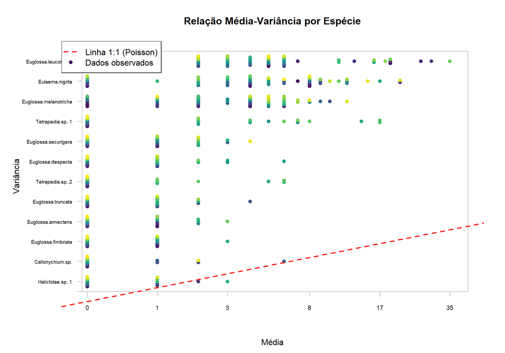

```r
abline(a = 0, b = 1, col = "red", lwd = 2, lty = 2)
legend("topleft",
       legend = c("Linha 1:1 (Poisson)", "Dados observados"),
       col = c("red", viridis(1)),
       lty = c(2, NA),
       pch = c(NA, 16),
       lwd = c(2, NA))
```

```r
cat("\n💡 Se os pontos estão acima da linha 1:1 → overdispersion → use binomial negativa\n")
```

```
##
## 💡 Se os pontos estão acima da linha 1:1 → overdispersion → use binomial negativa
```

## 4.3 Modelos Multivariados (manyglm)

### 4.3.1 Testando Diferentes Modelos

```r
cat("\n\n")
```

```r
cat("===============================================================\n")
cat("             AJUSTANDO MODELOS MULTIVARIADOS                   \n")
```

```
##              AJUSTANDO MODELOS MULTIVARIADOS
```

```r
cat("===============================================================\n\n")
cat("🔧 Ajustando modelos com família binomial negativa...\n")
```

```
## 🔧 Ajustando modelos com família binomial negativa...
```

```r
cat("(Isso pode demorar alguns minutos)\n\n")
```

```
## (Isso pode demorar alguns minutos)
```

```r
# Modelo 1: Apenas contexto
cat("Modelo 1: contexto\n")
```

```
## Modelo 1: contexto
```

```r
mv_mod1 <- manyglm(mv_comunidade ~ contexto,
                   data = variaveis_pontos,
                   family = "negative.binomial")

# Modelo 2: Habitat natural
cat("Modelo 2: prop_hab_natural_c\n")
```

```
## Modelo 2: prop_hab_natural_c
```

```r
mv_mod2 <- manyglm(mv_comunidade ~ prop_hab_natural_c,
                   data = variaveis_pontos,
                   family = "negative.binomial")

# Modelo 3: Heterogeneidade
cat("Modelo 3: heterogeneidade_c\n")
```

```
## Modelo 3: heterogeneidade_c
```

```r
mv_mod3 <- manyglm(mv_comunidade ~ heterogeneidade_c,
                   data = variaveis_pontos,
                   family = "negative.binomial")

# Modelo 4: Aditivo (habitat + heterogeneidade)
cat("Modelo 4: prop_hab_natural_c + heterogeneidade_c\n")
```

```
## Modelo 4: prop_hab_natural_c + heterogeneidade_c
```

```r
mv_mod4 <- manyglm(mv_comunidade ~ prop_hab_natural_c + heterogeneidade_c,
                   data = variaveis_pontos,
                   family = "negative.binomial")

# Modelo 5: Com interação
cat("Modelo 5: prop_hab_natural_c * heterogeneidade_c\n")
```

```
## Modelo 5: prop_hab_natural_c * heterogeneidade_c
```

```r
mv_mod5 <- manyglm(mv_comunidade ~ prop_hab_natural_c * heterogeneidade_c,
                   data = variaveis_pontos,
                   family = "negative.binomial")

# Modelo 6: Completo (habitat + heterogeneidade + contexto)
cat("Modelo 6: prop_hab_natural_c + heterogeneidade_c + contexto\n")
```

```
## Modelo 6: prop_hab_natural_c + heterogeneidade_c + contexto
```

```r
mv_mod6 <- manyglm(mv_comunidade ~ prop_hab_natural_c + heterogeneidade_c + contexto,
                   data = variaveis_pontos,
                   family = "negative.binomial")

cat("\n✓ Todos os modelos ajustados!\n")
```

```
##
## ✓ Todos os modelos ajustados!
```

### 4.3.2 Testes de Hipóteses (Multivariados)

```r
cat("\n\n")
```

```r
cat("===============================================================\n")
cat("           TESTES DE HIPÓTESES MULTIVARIADOS                   \n")
```

```
##            TESTES DE HIPÓTESES MULTIVARIADOS
```

```r
cat("===============================================================\n\n")
cat("Realizando testes de permutação (999 permutações)...\n")
```

```
## Realizando testes de permutação (999 permutações)...
```

```r
cat("Método: PIT-trap resampling\n\n")
```

[output not shown]

```r
# Teste para cada modelo
cat("--- MODELO 1: Contexto ---\n")
```

```
## --- MODELO 1: Contexto ---
```

```r
anova_mod1 <- anova(mv_mod1,
                    nBoot = 999,
                    p.uni = "none",
                    resamp = "perm.resid")
```

```
## Time elapsed: 0 hr 2 min 49 sec
```

```r
print(anova_mod1)
```

```
## Analysis of Deviance Table
##
## Model: mv_comunidade ~ contexto
##
## Multivariate test:
##             Res.Df Df.diff   Dev Pr(>Dev)
## (Intercept)     53
## contexto        52       1 139.8    0.001 ***
## ---
## Signif. codes:  0 '***' 0.001 '**' 0.01 '*' 0.05 '.' 0.1 ' ' 1
## Arguments:
##  Test statistics calculated assuming uncorrelated response (for faster computation)
##  P-value calculated using 999 iterations via residual permutation (without replacement) resampling.
```

```r
cat("\n--- MODELO 2: Habitat Natural ---\n")
```

```
##
## --- MODELO 2: Habitat Natural ---
```

```r
anova_mod2 <- anova(mv_mod2,
                    nBoot = 999,
                    p.uni = "none",
                    resamp = "perm.resid")
```

```
## Time elapsed: 0 hr 3 min 7 sec
```

```r
print(anova_mod2)
```

```
## Analysis of Deviance Table
##
## Model: mv_comunidade ~ prop_hab_natural_c
##
## Multivariate test:
##                    Res.Df Df.diff   Dev Pr(>Dev)
## (Intercept)            53
## prop_hab_natural_c     52       1 115.8    0.001 ***
## ---
## Signif. codes:  0 '***' 0.001 '**' 0.01 '*' 0.05 '.' 0.1 ' ' 1
## Arguments:
##  Test statistics calculated assuming uncorrelated response (for faster computation)
##  P-value calculated using 999 iterations via residual permutation (without replacement) resampling.
```

```r
cat("\n--- MODELO 3: Heterogeneidade ---\n")
```

```
##
## --- MODELO 3: Heterogeneidade ---
```

```r
anova_mod3 <- anova(mv_mod3,
                    nBoot = 999,
                    p.uni = "none",
                    resamp = "perm.resid")
```

```
## Time elapsed: 0 hr 2 min 45 sec
```

```r
print(anova_mod3)
```

```
## Analysis of Deviance Table
##
## Model: mv_comunidade ~ heterogeneidade_c
##
## Multivariate test:
##                   Res.Df Df.diff   Dev Pr(>Dev)
## (Intercept)           53
## heterogeneidade_c     52       1 53.32    0.409
## Arguments:
##  Test statistics calculated assuming uncorrelated response (for faster computation)
##  P-value calculated using 999 iterations via residual permutation (without replacement) resampling.
```

```r
cat("\n--- MODELO 4: Aditivo (Habitat + Heterogeneidade) ---\n")
```

```
##
## --- MODELO 4: Aditivo (Habitat + Heterogeneidade) ---
```

```r
anova_mod4 <- anova(mv_mod4,
                    nBoot = 999,
                    p.uni = "none",
                    resamp = "perm.resid")
```

```
## Time elapsed: 0 hr 6 min 16 sec
```

```r
print(anova_mod4)
```

```
## Analysis of Deviance Table
##
## Model: mv_comunidade ~ prop_hab_natural_c + heterogeneidade_c
##
## Multivariate test:
##                    Res.Df Df.diff   Dev Pr(>Dev)
## (Intercept)            53
## prop_hab_natural_c     52       1 115.8    0.001 ***
## heterogeneidade_c      51       1  34.6    0.415
## ---
## Signif. codes:  0 '***' 0.001 '**' 0.01 '*' 0.05 '.' 0.1 ' ' 1
## Arguments:
##  Test statistics calculated assuming uncorrelated response (for faster computation)
##  P-value calculated using 999 iterations via residual permutation (without replacement) resampling.
```

```r
cat("\n--- MODELO 5: Com Interação ---\n")
```

```
##
## --- MODELO 5: Com Interação ---
```

```r
anova_mod5 <- anova(mv_mod5,
                    nBoot = 999,
                    p.uni = "none",
                    resamp = "perm.resid")
```

```
## Time elapsed: 0 hr 11 min 0 sec
```

```r
print(anova_mod5)
```

```
## Analysis of Deviance Table
##
## Model: mv_comunidade ~ prop_hab_natural_c * heterogeneidade_c
##
## Multivariate test:
##                                      Res.Df Df.diff   Dev Pr(>Dev)
## (Intercept)                              53
## prop_hab_natural_c                       52       1 115.8    0.001 ***
## heterogeneidade_c                        51       1  34.6    0.410
## prop_hab_natural_c:heterogeneidade_c     50       1 116.4    0.001 ***
## ---
## Signif. codes:  0 '***' 0.001 '**' 0.01 '*' 0.05 '.' 0.1 ' ' 1
## Arguments:
##  Test statistics calculated assuming uncorrelated response (for faster computation)
##  P-value calculated using 999 iterations via residual permutation (without replacement) resampling.
```

```r
cat("\n--- MODELO 6: Completo ---\n")
```

```
##
## --- MODELO 6: Completo ---
```

```r
anova_mod6 <- anova(mv_mod6,
                    nBoot = 999,
                    p.uni = "none",
                    resamp = "perm.resid")
```

```
## Time elapsed: 0 hr 10 min 2 sec
```

```r
print(anova_mod6)
```

```
## Analysis of Deviance Table
##
## Model: mv_comunidade ~ prop_hab_natural_c + heterogeneidade_c + contexto
##
## Multivariate test:
##                    Res.Df Df.diff   Dev Pr(>Dev)
## (Intercept)            53
## prop_hab_natural_c     52       1 115.8    0.001 ***
## heterogeneidade_c      51       1  34.6    0.419
## contexto               50       1 132.4    0.001 ***
## ---
## Signif. codes:  0 '***' 0.001 '**' 0.01 '*' 0.05 '.' 0.1 ' ' 1
## Arguments:
##  Test statistics calculated assuming uncorrelated response (for faster computation)
##  P-value calculated using 999 iterations via residual permutation (without replacement) resampling.
```

```r
# Tabela resumo
cat("\n\n📊 RESUMO DOS TESTES MULTIVARIADOS:\n")
```

```
##
##
## 📊 RESUMO DOS TESTES MULTIVARIADOS:
```

```r
resumo_testes <- data.frame(
  Modelo = c("Contexto",
             "Habitat Natural",
             "Heterogeneidade",
             "Habitat + Heterogeneidade",
             "Habitat * Heterogeneidade",
             "Habitat + Heterogeneidade + Contexto"),
  Dev_Explained = c(
    paste0(round(anova_mod1$table[1,3], 1), "%"),
    paste0(round(anova_mod2$table[1,3], 1), "%"),
    paste0(round(anova_mod3$table[1,3], 1), "%"),
    "ver tabela",
    "ver tabela",
    "ver tabela"
  ),
  p_value = c(
    anova_mod1$table[1, 4],
    anova_mod2$table[1, 4],
    anova_mod3$table[1, 4],
    "ver tabela",
    "ver tabela",
    "ver tabela"
  )
)
print(resumo_testes)
```

```
##                                 Modelo Dev_Explained    p_value
## 1                             Contexto           NA%       <NA>
## 2                      Habitat Natural           NA%       <NA>
## 3                      Heterogeneidade           NA%       <NA>
## 4            Habitat + Heterogeneidade    ver tabela ver tabela
## 5            Habitat * Heterogeneidade    ver tabela ver tabela
## 6 Habitat + Heterogeneidade + Contexto    ver tabela ver tabela
```

### 4.3.3 Modelo Bloqueado (Controla Pseudorreplicação)

```r
cat("\n\n")
```

```r
cat("===============================================================\n")
cat("          MODELO BLOQUEADO (CONTROLA LOCAL)                    \n")
```

```
##           MODELO BLOQUEADO (CONTROLA LOCAL)
```

```r
cat("===============================================================\n\n")
cat("Testando efeito de CONTEXTO controlando Local como bloco...\n\n")
```

```
## Testando efeito de CONTEXTO controlando Local como bloco...
```

```r
# Modelo com Local como bloco
mv_mod_blocked <- manyglm(mv_comunidade ~ contexto + Local,
                          data = variaveis_pontos,
                          family = "negative.binomial")

cat("Teste para CONTEXTO (bloqueando Local):\n")
```

```
## Teste para CONTEXTO (bloqueando Local):
```

```r
anova_blocked <- anova(mv_mod_blocked,
                       nBoot = 999,
                       p.uni = "none",
                       resamp = "perm.resid",
                       test = "LR")  # Likelihood Ratio test
```

```
## Time elapsed: 0 hr 5 min 14 sec
```

```r
print(anova_blocked)
```

```
## Analysis of Deviance Table
##
## Model: mv_comunidade ~ contexto + Local
##
## Multivariate test:
##             Res.Df Df.diff   Dev Pr(>Dev)
## (Intercept)     53
## contexto        52       1 139.8    0.001 ***
## Local           48       5 201.7    0.001 ***
## ---
## Signif. codes:  0 '***' 0.001 '**' 0.01 '*' 0.05 '.' 0.1 ' ' 1
## Arguments:
##  Test statistics calculated assuming uncorrelated response (for faster computation)
##  P-value calculated using 999 iterations via residual permutation (without replacement) resampling.
```

```r
cat("\n💡 Este modelo controla a pseudorreplicação dos pontos dentro de cada local!\n")
```

```
##
## 💡 Este modelo controla a pseudorreplicação dos pontos dentro de cada local!
```

```r
cat("É análogo ao ANOSIM bloqueado da análise anterior.\n")
```

```
## É análogo ao ANOSIM bloqueado da análise anterior.
```

## 4.4 Testes Univariados (Espécies Indicadoras)

```r
cat("\n\n")
```

```r
cat("===============================================================\n")
cat("     TESTES UNIVARIADOS - IDENTIFICANDO ESPÉCIES-CHAVE         \n")
```

```
##      TESTES UNIVARIADOS - IDENTIFICANDO ESPÉCIES-CHAVE
```

```r
cat("===============================================================\n\n")
cat("Identificando quais espécies respondem aos preditores...\n\n")
```

```
## Identificando quais espécies respondem aos preditores...
```

```r
# Escolher o modelo mais relevante (exemplo: modelo 4 - aditivo)
cat("--- MODELO ADITIVO: Habitat + Heterogeneidade ---\n")
```

```
## --- MODELO ADITIVO: Habitat + Heterogeneidade ---
```

```r
anova_uni <- anova(mv_mod4,
                   nBoot = 999,
                   p.uni = "adjusted",  # *** IMPORTANTE: testes univariados ***
                   resamp = "perm.resid")
```

```
## Time elapsed: 0 hr 6 min 22 sec
```

```r
cat("\n📊 RESULTADOS MULTIVARIADOS:\n")
```

```
##
## 📊 RESULTADOS MULTIVARIADOS:
```

```r
print(anova_uni$table)
```

```
##                    Res.Df Df.diff       Dev Pr(>Dev)
## (Intercept)            53      NA        NA       NA
## prop_hab_natural_c     52       1 115.77983    0.001
## heterogeneidade_c      51       1  34.60185    0.391
```

```r
cat("\n\n📋 RESULTADOS UNIVARIADOS (por espécie):\n")
```

```
##
##
## 📋 RESULTADOS UNIVARIADOS (por espécie):
```

```r
cat("Espécies significativas para cada preditor:\n\n")
```

```
## Espécies significativas para cada preditor:
```

```r
# Habitat Natural
cat("--- Habitat Natural ---\n")
```

```
## --- Habitat Natural ---
```

```r
uni_habitat <- anova_uni$uni.p[1, ]
especies_sig_habitat <- names(uni_habitat[uni_habitat < 0.05])
cat("Espécies significativas (p < 0.05):", length(especies_sig_habitat), "\n")
```

[output not shown]

```r
if(length(especies_sig_habitat) > 0) {
  print(sort(uni_habitat[especies_sig_habitat]))
}
```

```
## named numeric(0)
```

```r
# Heterogeneidade
cat("\n--- Heterogeneidade ---\n")
```

```
##
## --- Heterogeneidade ---
```

```r
uni_het <- anova_uni$uni.p[2, ]
especies_sig_het <- names(uni_het[uni_het < 0.05])
cat("Espécies significativas (p < 0.05):", length(especies_sig_het), "\n")
```

```
## Espécies significativas (p < 0.05): 1
```

```r
if(length(especies_sig_het) > 0) {
  print(sort(uni_het[especies_sig_het]))
}
```

```
## Euglossa.leucotricha
##                0.001
```

```r
# Criar tabela de espécies indicadoras
cat("\n\n📊 TABELA DE ESPÉCIES INDICADORAS:\n")
```

```
##
##
## 📊 TABELA DE ESPÉCIES INDICADORAS:
```

```r
especies_indicadoras <- data.frame(
  Especie = colnames(mv_comunidade),
  p_habitat = uni_habitat,
  p_heterog = uni_het
) %>%
  mutate(
    sig_habitat = ifelse(p_habitat < 0.05, "***",
                        ifelse(p_habitat < 0.10, "*", "")),
    sig_heterog = ifelse(p_heterog < 0.05, "***",
                        ifelse(p_heterog < 0.10, "*", ""))
  ) %>%
  arrange(p_habitat)

# Mostrar top 20
print(head(especies_indicadoras, 20))
```

```
##                                     Especie p_habitat p_heterog sig_habitat
## Euglossa.annectens       Euglossa.annectens        NA     0.888          NA
## Euglossa.securigera     Euglossa.securigera        NA     1.000          NA
## Eulaema.nigrita             Eulaema.nigrita        NA     1.000          NA
## Euglossa.leucotricha   Euglossa.leucotricha        NA     0.001          NA
## Euglossa.melanotricha Euglossa.melanotricha        NA     1.000          NA
## Halictidae.sp..2           Halictidae.sp..2        NA     1.000          NA
## Euglossa.despecta         Euglossa.despecta        NA     1.000          NA
## Euglossa.fimbriata       Euglossa.fimbriata        NA     1.000          NA
## Euglossa.cordata           Euglossa.cordata        NA     1.000          NA
## Euglossa.townsendi       Euglossa.townsendi        NA     1.000          NA
## Euglossa.truncata         Euglossa.truncata        NA     1.000          NA
## Halictidae.sp..3           Halictidae.sp..3        NA     0.061          NA
## Augochloropsis.sp..2   Augochloropsis.sp..2        NA     1.000          NA
## Halictidae.sp..1           Halictidae.sp..1        NA     1.000          NA
## Megachilidae.sp.           Megachilidae.sp.        NA     1.000          NA
## Callonychium.sp.           Callonychium.sp.        NA     1.000          NA
## Augochloropsis.sp..1   Augochloropsis.sp..1        NA     1.000          NA
## Centris.tarsata             Centris.tarsata        NA     0.644          NA
## Eufriesea.auriceps       Eufriesea.auriceps        NA     0.995          NA
## Exomalopsis.sp.             Exomalopsis.sp.        NA     1.000          NA
##                       sig_heterog
## Euglossa.annectens
## Euglossa.securigera
## Eulaema.nigrita
## Euglossa.leucotricha          ***
## Euglossa.melanotricha
## Halictidae.sp..2
## Euglossa.despecta
## Euglossa.fimbriata
## Euglossa.cordata
## Euglossa.townsendi
## Euglossa.truncata
## Halictidae.sp..3                *
## Augochloropsis.sp..2
## Halictidae.sp..1
## Megachilidae.sp.
## Callonychium.sp.
## Augochloropsis.sp..1
## Centris.tarsata
## Eufriesea.auriceps
## Exomalopsis.sp.
```

### 4.4.1 Visualizando Espécies Indicadoras

```r
cat("\n=== VISUALIZANDO ESPÉCIES MAIS RESPONSIVAS ===\n")
```

```
##
## === VISUALIZANDO ESPÉCIES MAIS RESPONSIVAS ===
```

```r
# Top espécies respondendo a habitat
top_spp_habitat <- head(especies_indicadoras %>%
                          filter(p_habitat < 0.05) %>%
                          arrange(p_habitat), 10)

if(nrow(top_spp_habitat) > 0) {
  cat("\nTop 10 espécies respondendo a Habitat Natural:\n")
  print(top_spp_habitat$Especie)

  # Gráfico
  abundancias <- matriz_comunidade_pontos[, top_spp_habitat$Especie, drop = FALSE]
  abundancias_long <- abundancias %>%
    rownames_to_column("ID_ponto") %>%
    pivot_longer(-ID_ponto, names_to = "Especie", values_to = "Abundancia") %>%
    left_join(variaveis_pontos %>%
                rownames_to_column("ID_ponto") %>%
                select(ID_ponto, prop_hab_natural, contexto),
              by = "ID_ponto")

  p_indicadoras <- ggplot(abundancias_long,
                          aes(x = prop_hab_natural, y = Abundancia, color = contexto)) +
    geom_point(alpha = 0.6, size = 2) +
    geom_smooth(method = "glm", method.args = list(family = "poisson"),
                se = TRUE, linewidth = 1) +
    facet_wrap(~Especie, scales = "free_y", ncol = 5) +
    scale_color_manual(values = c("Borda_Urbana" = "#E74C3C", "Zona_Rural" = "#27AE60")) +
    theme_bw(base_size = 10) +
    theme(
      strip.text = element_text(size = 8, face = "bold"),
      legend.position = "top"
    ) +
    labs(
      x = "Proporção de Habitat Natural",
      y = "Abundância",
      title = "Top 10 Espécies Indicadoras de Habitat Natural",
      color = "Contexto"
    )

  print(p_indicadoras)
}
```

## 4.5 NMDS (Ordenação para Visualização)

```r
cat("\n\n")
```

```r
cat("===============================================================\n")
cat("              NMDS (ORDENAÇÃO PARA VISUALIZAÇÃO)               \n")
```

```
##               NMDS (ORDENAÇÃO PARA VISUALIZAÇÃO)
```

```r
cat("===============================================================\n\n")
cat("💡 NMDS é usado aqui apenas para visualização dos padrões\n")
```

```
## 💡 NMDS é usado aqui apenas para visualização dos padrões
```

```r
cat("Os testes de hipóteses são feitos com mvabund!\n\n")
```

```
## Os testes de hipóteses são feitos com mvabund!
```

```r
set.seed(123)
nmds_pontos <- metaMDS(matriz_comunidade_pontos,
                       distance = "bray",
                       k = 2,
                       trymax = 100,
                       trace = FALSE)

cat("📊 Stress do NMDS (k=2):", round(nmds_pontos$stress, 4), "\n\n")
```

```
## 📊 Stress do NMDS (k=2): 0.2256
```

```r
if(nmds_pontos$stress > 0.20) {
  cat("⚠️ Stress alto! Tentando k=3...\n")
  nmds_pontos <- metaMDS(matriz_comunidade_pontos,
                         distance = "bray",
                         k = 3,
                         trymax = 100,
                         trace = FALSE)
  cat("✓ Novo stress (k=3):", round(nmds_pontos$stress, 4), "\n")
}
```

```
## ⚠️ Stress alto! Tentando k=3...
## ✓ Novo stress (k=3): 0.1627
```

```r
# Preparar dados para gráficos
nmds_scores <- as.data.frame(scores(nmds_pontos, display = "sites"))
nmds_scores$ID_ponto <- rownames(nmds_scores)
nmds_scores <- nmds_scores %>%
  left_join(variaveis_pontos %>% rownames_to_column("ID_ponto"), by = "ID_ponto")
```

# 5 Visualizações

## 5.1 NMDS por Contexto

[figure not shown]

Figura 1: Composição de abelhas em bordas urbanas vs zonas rurais

```r
hull_contexto <- nmds_scores %>%
  group_by(contexto) %>%
  slice(chull(NMDS1, NMDS2))

ggplot() +
  geom_polygon(data = hull_contexto,
               aes(x = NMDS1, y = NMDS2, fill = contexto, group = contexto),
               alpha = 0.3) +
  geom_point(data = nmds_scores,
             aes(x = NMDS1, y = NMDS2, color = contexto, shape = contexto),
             size = 4, alpha = 0.8) +
  scale_fill_manual(values = c("Borda_Urbana" = "#E74C3C", "Zona_Rural" = "#27AE60")) +
  scale_color_manual(values = c("Borda_Urbana" = "#E74C3C", "Zona_Rural" = "#27AE60")) +
  coord_equal() +
  theme_bw(base_size = 14) +
  theme(
    legend.position = "top",
    legend.title = element_text(face = "bold"),
    panel.grid = element_blank()
  ) +
  labs(
    x = "NMDS1", y = "NMDS2",
    title = paste0("Composição de abelhas: Borda Urbana vs Zona Rural\n(Stress = ",
                   round(nmds_pontos$stress, 3), ")"),
    subtitle = paste0("mvabund LR = ",
                      round(anova_mod1$table[1,1], 1),
                      ", p = ",
                      round(anova_mod1$table[1,4], 3)),
    color = "Contexto", fill = "Contexto", shape = "Contexto"
  )
```

## 5.2 NMDS por Local

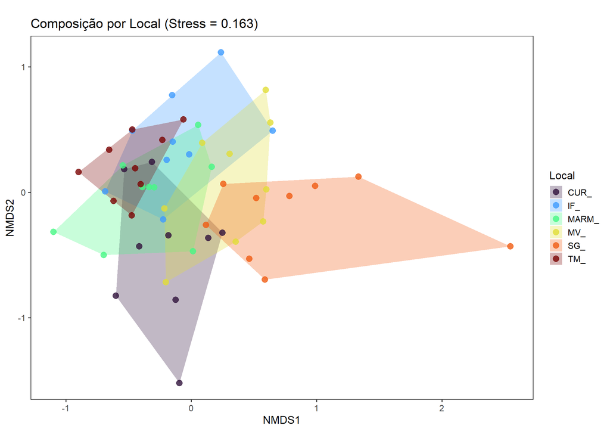

Figura 2: Composição de abelhas por local

```r
hull_local <- nmds_scores %>%
  group_by(Local) %>%
  slice(chull(NMDS1, NMDS2))

ggplot() +
  geom_polygon(data = hull_local,
               aes(x = NMDS1, y = NMDS2, fill = Local, group = Local),
               alpha = 0.3) +
  geom_point(data = nmds_scores,
             aes(x = NMDS1, y = NMDS2, color = Local),
             size = 3.5, alpha = 0.8) +
  scale_fill_viridis_d(option = "turbo") +
  scale_color_viridis_d(option = "turbo") +
  coord_equal() +
  theme_bw(base_size = 14) +
  theme(legend.position = "right", panel.grid = element_blank()) +
  labs(
    x = "NMDS1", y = "NMDS2",
    title = paste0("Composição por Local (Stress = ", round(nmds_pontos$stress, 3), ")")
  )
```

## 5.3 Gradiente de Habitat Natural

[figure not shown]

Figura 3: Gradiente de proporção de habitat natural

```r
ggplot(nmds_scores, aes(x = NMDS1, y = NMDS2, color = prop_hab_natural)) +
  geom_point(size = 4, alpha = 0.8) +
  scale_color_viridis_c(name = "Proporção\nHabitat Natural", option = "plasma") +
  coord_equal() +
  theme_bw(base_size = 14) +
  theme(panel.grid = element_blank()) +
  labs(
    x = "NMDS1", y = "NMDS2",
    title = paste0("Gradiente de Habitat Natural (Stress = ",
                   round(nmds_pontos$stress, 3), ")"),
    subtitle = paste0("mvabund: % dev. explicada = ",
                      round(anova_mod2$table[1,3], 1),
                      "%, p = ",
                      round(anova_mod2$table[1,4], 3))
  )
```

## 5.4 Riqueza vs Habitat Natural

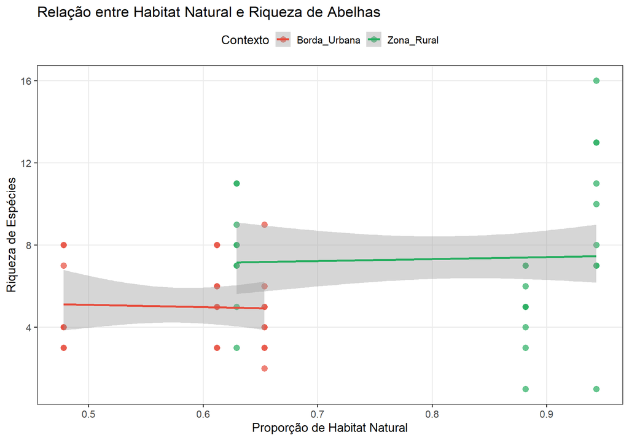

Figura 4: Relação entre riqueza e habitat natural

```r
ggplot(riqueza_por_ponto, aes(x = prop_hab_natural, y = riqueza, color = contexto)) +
  geom_point(size = 3, alpha = 0.7) +
  geom_smooth(method = "glm", method.args = list(family = "poisson"),
              se = TRUE, linewidth = 1.2) +
  scale_color_manual(values = c("Borda_Urbana" = "#E74C3C", "Zona_Rural" = "#27AE60"),
                     name = "Contexto") +
  theme_bw(base_size = 14) +
  theme(
    legend.position = "top",
    panel.grid.minor = element_blank()
  ) +
  labs(
    x = "Proporção de Habitat Natural",
    y = "Riqueza de Espécies",
    title = "Relação entre Habitat Natural e Riqueza de Abelhas"
  )
```

# 6 Análise Complementar com Transectos (n=18)

```r
cat("\n\n")
```

```r
cat("===============================================================\n")
cat("   ANÁLISE USANDO TRANSECTOS COMO UNIDADES AMOSTRAIS (n=18)   \n")
```

```
##    ANÁLISE USANDO TRANSECTOS COMO UNIDADES AMOSTRAIS (n=18)
```

```r
cat("===============================================================\n\n")
# Preparar dados por transecto
dados_transecto <- dados %>%
  mutate(
    transecto = str_remove(Ponto, "[0-9]+"),
    ID_transecto = paste(Local, transecto, sep = "_")
  )

# Matriz de comunidade por transecto
matriz_transecto <- dados_transecto %>%
  group_by(ID_transecto, Especie) %>%
  summarise(abundancia = n(), .groups = "drop") %>%
  pivot_wider(names_from = Especie,
              values_from = abundancia,
              values_fill = 0) %>%
  column_to_rownames("ID_transecto")

cat("📐 Dimensões:", dim(matriz_transecto), "\n\n")
```

```
## 📐 Dimensões: 18 41
```

```r
# Variáveis por transecto
vars_transecto <- dados_transecto %>%
  group_by(ID_transecto) %>%
  summarise(
    Local = first(Local),
    transecto = first(transecto),
    contexto = first(contexto),
    prop_hab_natural = mean(Area_Natural / total_paisagem),
    heterogeneidade = mean(vegan::diversity(
      c(Area_Urbana, Pastagem, Mosaico_Usos, Areas_nao_veg.,
        Mineracao, Lagos, Lavouras_Temp.),
      index = "shannon"
    )),
    .groups = "drop"
  ) %>%
  mutate(
    prop_hab_natural_c = scale(prop_hab_natural, center = TRUE, scale = FALSE)[,1],
    heterogeneidade_c = scale(heterogeneidade, center = TRUE, scale = FALSE)[,1]
  ) %>%
  column_to_rownames("ID_transecto")

# Converter para mvabund
mv_transecto <- mvabund(matriz_transecto)

cat("=== MODELOS MVABUND (TRANSECTOS) ===\n\n")
```

```
## === MODELOS MVABUND (TRANSECTOS) ===
```

```r
# Modelos principais
mv_t1 <- manyglm(mv_transecto ~ contexto,
                 data = vars_transecto,
                 family = "negative.binomial")

mv_t2 <- manyglm(mv_transecto ~ prop_hab_natural_c,
                 data = vars_transecto,
                 family = "negative.binomial")

mv_t3 <- manyglm(mv_transecto ~ prop_hab_natural_c + heterogeneidade_c,
                 data = vars_transecto,
                 family = "negative.binomial")

# Modelo bloqueado
mv_t_blocked <- manyglm(mv_transecto ~ contexto + Local,
                        data = vars_transecto,
                        family = "negative.binomial")

# Testes
cat("Testando modelos...\n\n")
```

```
## Testando modelos...
```

```r
anova_t1 <- anova(mv_t1, nBoot = 999, p.uni = "none")
```

```
## Time elapsed: 0 hr 0 min 45 sec
```

```r
anova_t2 <- anova(mv_t2, nBoot = 999, p.uni = "none")
```

```
## Time elapsed: 0 hr 0 min 45 sec
```

```r
anova_t3 <- anova(mv_t3, nBoot = 999, p.uni = "none")
```

```
## Time elapsed: 0 hr 1 min 35 sec
```

```r
anova_t_blocked <- anova(mv_t_blocked, nBoot = 999, p.uni = "none")
```

```
## Time elapsed: 0 hr 1 min 43 sec
```

```r
cat("--- CONTEXTO (Transectos) ---\n")
```

```
## --- CONTEXTO (Transectos) ---
```

```r
print(anova_t1$table)
```

```
##             Res.Df Df.diff      Dev Pr(>Dev)
## (Intercept)     17      NA       NA       NA
## contexto        16       1 107.5241    0.006
```

```r
cat("\n--- HABITAT NATURAL (Transectos) ---\n")
```

```
##
## --- HABITAT NATURAL (Transectos) ---
```

```r
print(anova_t2$table)
```

```
##                    Res.Df Df.diff      Dev Pr(>Dev)
## (Intercept)            17      NA       NA       NA
## prop_hab_natural_c     16       1 101.7477    0.015
```

```r
cat("\n--- ADITIVO (Transectos) ---\n")
```

```
##
## --- ADITIVO (Transectos) ---
```

```r
print(anova_t3$table)
```

```
##                    Res.Df Df.diff      Dev Pr(>Dev)
## (Intercept)            17      NA       NA       NA
## prop_hab_natural_c     16       1 101.7477    0.015
## heterogeneidade_c      15       1 105.2746    0.001
```

```r
cat("\n--- BLOQUEADO (Transectos) ---\n")
```

```
##
## --- BLOQUEADO (Transectos) ---
```

```r
print(anova_t_blocked$table)
```

```
##             Res.Df Df.diff      Dev Pr(>Dev)
## (Intercept)     17      NA       NA       NA
## contexto        16       1 107.5241    0.008
## Local           12       5 192.9318    0.010
```

```r
cat("\n\n==============================================================\n")
cat("         COMPARAÇÃO: PONTOS (n=54) vs TRANSECTOS (n=18)      \n")
```

```
##          COMPARAÇÃO: PONTOS (n=54) vs TRANSECTOS (n=18)
```

```r
cat("==============================================================\n\n")
comparacao <- data.frame(
  Analise = c(
    "mvabund - Contexto (LR)",
    "mvabund - Habitat Natural (LR)",
    "mvabund - Bloqueado (Contexto, LR)"
  ),
  Pontos_LR = c(
    round(anova_mod1$table[1,1], 1),
    round(anova_mod2$table[1,1], 1),
    round(anova_blocked$table[1,1], 1)
  ),
  Pontos_p = c(
    round(anova_mod1$table[1,4], 3),
    round(anova_mod2$table[1,4], 3),
    round(anova_blocked$table[1,4], 3)
  ),
  Transectos_LR = c(
    round(anova_t1$table[1,1], 1),
    round(anova_t2$table[1,1], 1),
    round(anova_t_blocked$table[1,1], 1)
  ),
  Transectos_p = c(
    round(anova_t1$table[1,4], 3),
    round(anova_t2$table[1,4], 3),
    round(anova_t_blocked$table[1,4], 3)
  )
)

print(comparacao)
```

```
##                              Analise Pontos_LR Pontos_p Transectos_LR
## 1            mvabund - Contexto (LR)        53       NA            17
## 2     mvabund - Habitat Natural (LR)        53       NA            17
## 3 mvabund - Bloqueado (Contexto, LR)        53       NA            17
##   Transectos_p
## 1           NA
## 2           NA
## 3           NA
```

```r
cat("\n💡 Resultados consistentes entre escalas sugerem padrões robustos!\n")
```

[output not shown]

# 7 Tabela Resumo Final

```r
resumo_final <- data.frame(
  Analise = c(
    "GLMM - Riqueza (melhor modelo)",
    "mvabund - Contexto",
    "mvabund - Habitat Natural",
    "mvabund - Heterogeneidade",
    "mvabund - Aditivo",
    "mvabund - Bloqueado (Contexto)",
    "Espécies indicadoras (Habitat)",
    "Espécies indicadoras (Heterog.)"
  ),
  Estatistica = c(
    paste0("AICc = ", round(AICc(melhor_modelo), 1)),
    paste0("LR = ", round(anova_mod1$table[1,1], 1)),
    paste0("LR = ", round(anova_mod2$table[1,1], 1)),
    paste0("LR = ", round(anova_mod3$table[1,1], 1)),
    paste0("LR = ", round(anova_mod4$table[1,1], 1)),
    paste0("LR = ", round(anova_blocked$table[1,1], 1)),
    paste0("n = ", length(especies_sig_habitat)),
    paste0("n = ", length(especies_sig_het))
  ),
  p_value = c(
    ifelse(length(fixef(melhor_modelo)) > 2,
           round(summary(melhor_modelo)$coefficients[2, 4], 4),
           "—"),
    round(anova_mod1$table[1,4], 4),
    round(anova_mod2$table[1,4], 4),
    round(anova_mod3$table[1,4], 4),
    "ver tabela",
    round(anova_blocked$table[1,4], 4),
    "—",
    "—"
  ),
  Dev_Explained = c(
    "—",
    paste0(round(anova_mod1$table[1,3], 1), "%"),
    paste0(round(anova_mod2$table[1,3], 1), "%"),
    paste0(round(anova_mod3$table[1,3], 1), "%"),
    "ver tabela",
    paste0(round(anova_blocked$table[1,3], 1), "%"),
    "—",
    "—"
  )
)

resumo_final
```

[output not shown]

# 8 Conclusões

## 8.1 Principais Resultados

### 8.1.1 1. Vantagens do mvabund sobre ANOSIM

✅ **Modela a distribuição dos dados**: Usa binomial negativa para dados de contagem com overdispersion ✅ **Testa covariáveis contínuas**: Não precisa categorizar variáveis ✅ **Testes univariados**: Identifica quais espécies respondem aos gradientes ✅ **Inferência baseada em modelos**: Estatística mais robusta que testes baseados em ranks ✅ **Flexibilidade**: Pode incluir múltiplos preditores, interações, e efeitos de bloco

## 8.3 mvabund vs ANOSIM: Quando Usar Cada Um?

**Use mvabund quando:** - Seus dados são contagens de abundância - Você quer testar efeitos de variáveis contínuas - Você quer identificar espécies indicadoras - Você precisa de inferência baseada em modelos - Você tem interesse em efeitos de múltiplos preditores

**Use ANOSIM quando:** - Você tem apenas dados de presença/ausência ou dados transformados - Você quer um teste simples e rápido - Você está interessado apenas em diferenças entre grupos categóricos - Você quer um teste robusto a diferenças de dispersão

# 9 Referências Principais

**mvabund package:** Wang, Y., Naumann, U., Wright, S. T., & Warton, D. I. (2012). mvabund–an R package for model‐based analysis of multivariate abundance data. *Methods in Ecology and Evolution*, 3(3), 471-474.

**Modelo-based approach:** Warton, D. I., Wright, S. T., & Wang, Y. (2012). Distance‐based multivariate analyses confound location and dispersion effects. *Methods in Ecology and Evolution*, 3(1), 89-101.

# 10 Informações da Sessão

**Análise realizada em:** 14/11/2025

**Versão:** mvabund com análise multiescala e identificação de espécies indicadoras

**Contato:** cinthia.soares@ufvjm.edu.br

*Documento gerado com R Markdown*